# lab8_forensics_CODIS_redux_solutions

## Calculating match probabilities -- for real

Last week we got our hands dirty doing some exploratory analysis and visualizations of DNA fingerprints. We also did some calculations. These were done ignoring the **diploidy** of the data. Now that we have a better handle on this dataset, we're going to do the same calculations *properly*.

```python
from datascience import *
%matplotlib inline
import matplotlib.pyplot as plots
import numpy as np
plots.style.use('fivethirtyeight')
```

### Import the data

Let's read in the raw data again.

```python
data_dir='https://raw.githubusercontent.com/shishiluo/Genomics-DataScience/master/data/'

raw_profiles=Table.read_table(data_dir+'CODIS_profiles.csv')
raw_profiles
```

| Group | SampleCode | AMEL | AMEL.1 | CSF1PO | CSF1PO.1 | D10S1248 | D10S1248.1 | D12S391 | D12S391.1 | D13S317 | D13S317.1 | D16S539 | D16S539.1 | D18S51 | D18S51.1 | D19S433 | D19S433.1 | D1S1656 | D1S1656.1 | D21S11 | D21S11.1 | D22S1045 | D22S1045.1 | D2S1338 | D2S1338.1 | D2S441 | D2S441.1 | D3S1358 | D3S1358.1 | … |
| --- | --- | --- | --- | --- | --- | --- | --- | --- | --- | --- | --- | --- | --- | --- | --- | --- | --- | --- | --- | --- | --- | --- | --- | --- | --- | --- | --- | --- | --- | --- |
| Cauc | BC11352 | X | Y | 11 | 13 | 13 | 15 | 17 | 18 | 13 | 13 | 8 | 12 | 13 | 15 | 13 | 13 | 14 | 16.3 | 28 | 30 | 14 | 16 | 17 | 20 | 14 | 15 | 14 | 17 | … |
| Hisp | GA05070 | X | Y | 10 | 12 | 12 | 14 | 17.3 | 23 | 10 | 11 | 10 | 10 | 16 | 18 | 14.2 | 15 | 14 | 16 | 30 | 33.2 | 14 | 15 | 19 | 23 | 11 | 15 | 16 | 18 | … |
| Hisp | GA05071 | X | Y | 11 | 15 | 14 | 16 | 19 | 20 | 11 | 12 | 12 | 12 | 17 | 17 | 13 | 13 | 16 | 16 | 30.2 | 32.2 | 15 | 16 | 17 | 17 | 10 | 10 | 14 | 17 | … |
| Cauc | GC03394 | X | Y | 10 | 12 | 15 | 16 | 19 | 19 | 11 | 11 | 12 | 13 | 15 | 17 | 14 | 15 | 12 | 15 | 30 | 31 | 15 | 16 | 17 | 20 | 11 | 12 | 15 | 18 | … |
| Cauc | GT36864 | X | Y | 10 | 12 | 15 | 17 | 17.3 | 20 | 11 | 11 | 11 | 12 | 14 | 19 | 13 | 14 | 16 | 17.3 | 31.2 | 32.2 | 11 | 16 | 19 | 25 | 10 | 14 | 15 | 16 | … |
| Cauc | GT36866 | X | Y | 11 | 11 | 13 | 16 | 18 | 20 | 11 | 12 | 11 | 13 | 13 | 15 | 12 | 14 | 11 | 14 | 31.2 | 32.2 | 16 | 17 | 18 | 20 | 11 | 14 | 16 | 17 | … |
| Cauc | GT36875 | X | Y | 11 | 11 | 13 | 14 | 18 | 19 | 11 | 12 | 11 | 13 | 14 | 17 | 12 | 14 | 11 | 18.3 | 28 | 28 | 15 | 16 | 24 | 25 | 11.3 | 14 | 14 | 16 | … |
| Cauc | GT36877 | X | Y | 11 | 11 | 14 | 15 | 17 | 20 | 11 | 11 | 9 | 11 | 16 | 18 | 13 | 16.2 | 12 | 15.3 | 28 | 30 | 11 | 16 | 18 | 22 | 11 | 12 | 15 | 18 | … |
| Cauc | GT36878 | X | Y | 10 | 12 | 13 | 14 | 18 | 18 | 11 | 13 | 8 | 11 | 13 | 17 | 13 | 15 | 15 | 17.3 | 30 | 32.2 | 14 | 15 | 17 | 18 | 11 | 14 | 15 | 18 | … |
| Cauc | GT36884 | X | Y | 10 | 11 | 13 | 13 | 17 | 18 | 11 | 11 | 8 | 12 | 14 | 15 | 12 | 15 | 12 | 13 | 28 | 30 | 16 | 16 | 17 | 24 | 13 | 14 | 14 | 16 | … |

... (1026 rows omitted)

**Q1**: Look at this table more closely. Is there anything you notice about the XXXX versus XXXX.1 columns that suggest a problem with ignoring the latter? (If you need a hint, compare histograms of the two columns associated with a few of the STR loci).

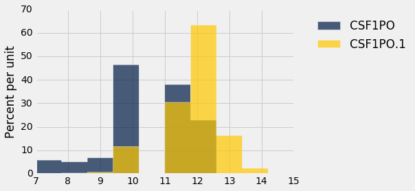

```python
raw_profiles.hist(['CSF1PO', 'CSF1PO.1'])
```

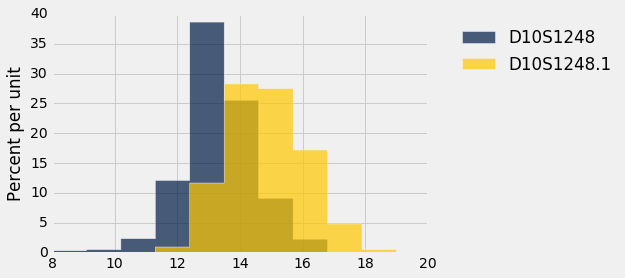

```python
raw_profiles.hist(['D10S1248', 'D10S1248.1'])
```

The left column always contains the lower valued allele, so it is not a representative sample of the alleles for that locus.

## Restricting to CODIS core loci but keeping information in both columns

Just like last time, we will restrict to the CODIS loci. We'll exclude 'AMEL' because it doesn't have quantitative alleles. We'll also keep 'Group' because it might be useful for further analysis later.

However, unlike last time, we'll include the information from both XXXX and XXXX.1 columns. There is more than one way to do this, so feel free to do it your way.

```python
# Append a copy of the 'Group' column
# to the original column
group=raw_profiles.column('Group')
new_group=np.array(list(group)*2)
# when you multiply a list by k, it concatenates
# itself with itself k-1 times

# initialize a new table with the column new_group
CODIS_profiles_new=Table()
CODIS_profiles_new.append_column('Ethnicity', new_group)

# for the other columns, loop through the loci, concatenate
# XXXX and XXXX.1 columns, and append to table
CODIS_loci=['TPOX', 'D3S1358', 'FGA', 'D5S818',
            'CSF1PO', 'D7S820', 'D8S1179', 'TH01', 'vWA',
            'D13S317', 'D16S539', 'D18S51', 'D21S11']
for l in CODIS_loci:
    col1=raw_profiles.column(l)
    col2=raw_profiles.column(l+'.1') # concatenate strings to get name of second column
    new_col=np.array(list(col1)+list(col2)) # concatenate lists, make into array
    CODIS_profiles_new.append_column(l, new_col)
```

**Q3**: Check that the distributions of alleles you get from `CODIS_profiles_new` do reflect the data from the second columns for each STR locus.

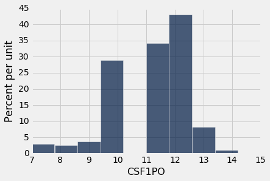

```python
CODIS_profiles_new.hist('CSF1PO')
```